# Introduction to ggplot2: Turkish Renewable Energy Production Data

Berk Orbay

# Introduction

Main purpose of this document is to introduce a major data visualization package, `ggplot2` with a contemporary subject. [Grammar of graphics](https://towardsdatascience.com/a-comprehensive-guide-to-the-grammar-of-graphics-for-effective-visualization-of-multi-dimensional-1f92b4ed4149) (hence the name, gg), is book written by Leland Wilkinson and it heavily influences ggplot2.

There are several basic concepts to create fundamental graphs. It is possible to do much more with additional functions and parameters but let’s first focus on the fundamentals: `ggplot` object, `+` operator to connect layers, `aes` function to set aesthetics (e.g. x and y), `geom_*` functions to define the plot.

## Preparations

There are two prerequisites to start: Install `tidyverse` package and putting the relevant data set into the working directory (write `getwd()` in the console to locate your working directory). In this document, topic of the data set is the hourly licensed and unlicensed renewable energy production data between January 1, 2018 and May 31, 2020.

To install the package run `install.packages("tidyverse")` in the console and select a mirror (first one is quite ok). Once you install the library you can always call it with `library(tidyverse)` command (**no need to reinstall**). You can download the data set from its **[GitHub Repository](https://github.com/berkorbay/datasets/raw/master/renewables_production/rp_201801_202005_df.rds)**.

```r
library(tidyverse) #tidyverse is a package group which includes dplyr as well
library(lubridate)
raw_df <- readRDS("rp_201801_202005_df.rds")
```

**Note:** We will use the same data and preparation process as the `dplyr` tutorial. We will also use some `dplyr` functionality as well. So, it is recommended to have an understanding of `dplyr` first.

# Fundamental Plots

We are going to use all these elements in plot examples.

## Scatter Plot

We use `geom_point` for scatter plot. Let’s create a scatterplot of licensed wind versus unlicensed solar production in May, 2020 and between hours 10 and 17. Let’s first create our data set `plot_df1`.

```r
plot_df1 <- raw_df %>% filter(dt >= "2020-05-01" & dt < "2020-06-01" & lubridate::hour(dt) >= 10 & lubridate::hour(dt) <= 17) %>% transmute(hour_of_day = lubridate::hour(dt),wind_lic,sun_ul)

print(plot_df1)
```

```
## # A tibble: 248 x 3
##   hour_of_day wind_lic sun_ul
##         <int>    <dbl>  <dbl>
## 1          17    2055.  1442.
## 2          16    2036.  2523.
## 3          15    1875.  3402.
## # … with 245 more rows
```

We will start with the canvas (`ggplot` object) then add the `geom_point` layer with `+`. The rest will be handled by ggplot2.

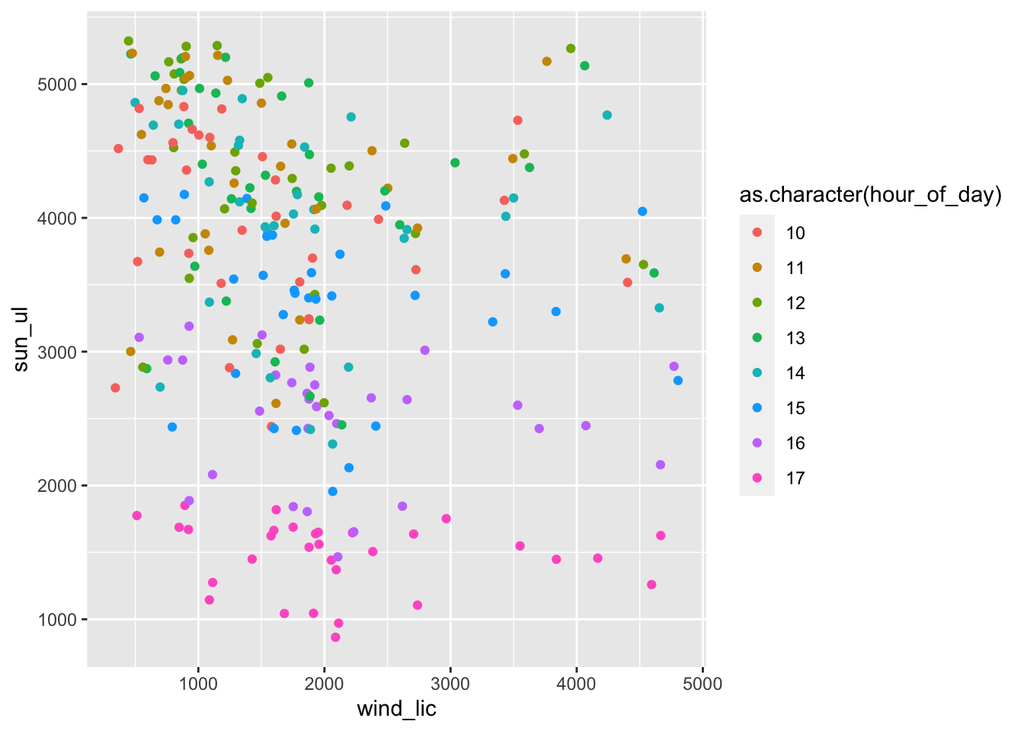

```r
ggplot(plot_df1) + geom_point(aes(x = wind_lic, y = sun_ul, color=as.character(hour_of_day)))
```

We could have defined the aesthetics in the first object. ggplot2 is quite flexible about it.

```r
ggplot(plot_df1,aes(x = wind_lic, y = sun_ul, color=as.character(hour_of_day))) + geom_point()
```

## Line Plot

Time series can be beautifully represented with a line plot. `ggplot2` has special properties and aggregations for date-time columns.

```r
plot_df2 <- raw_df %>% filter(dt >= "2020-05-01" & dt < "2020-06-01") %>% select(dt,wind_lic,sun_ul)

print(plot_df2)
```

```
## # A tibble: 744 x 3
##   dt                  wind_lic sun_ul
##   <dttm>                 <dbl>  <dbl>
## 1 2020-05-31 23:00:00    1434. 0.0582
## 2 2020-05-31 22:00:00    1577. 0.032
## 3 2020-05-31 21:00:00    1858. 0.0335
## # … with 741 more rows
```

It is also possible to combine `dplyr` with `ggplot2`, although excessive use is not recommended. We are going to use `pivot_longer` function to convert the data from wide to long format.

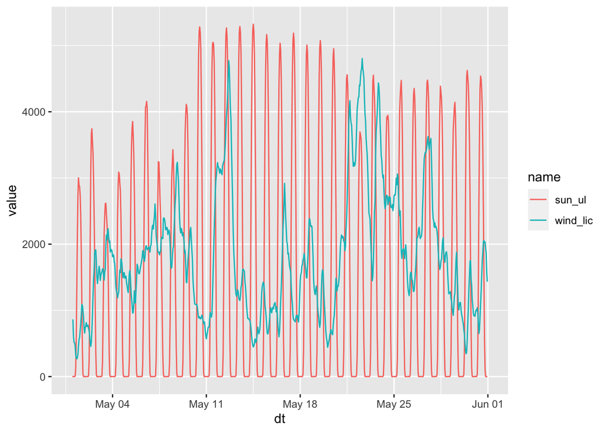

```r
plot_df2 %>% pivot_longer(.,-dt) %>% ggplot(.,aes(x=dt,y=value,color=name)) + geom_line()
```

## Bar Chart

You can create bar charts in a very similar manner. First, let’s create a data set where May 2020’s production is used and production type is differentiated as Licensed and Unlicensed in a different column.

```r
plot_df3 <- raw_df %>% filter(dt >= "2020-05-01" & dt < "2020-06-01") %>% summarise(across(-dt,sum)) %>% pivot_longer(.,everything()) %>% mutate(type = ifelse( grepl("_lic+$",name),"Licensed","Unlicensed"))

print(plot_df3)
```

```
## # A tibble: 16 x 3
##   name              value type
##   <chr>             <dbl> <chr>
## 1 wind_lic       1346260. Licensed
## 2 geothermal_lic  654089. Licensed
## 3 biogas_lic       56839. Licensed
## # … with 13 more rows
```

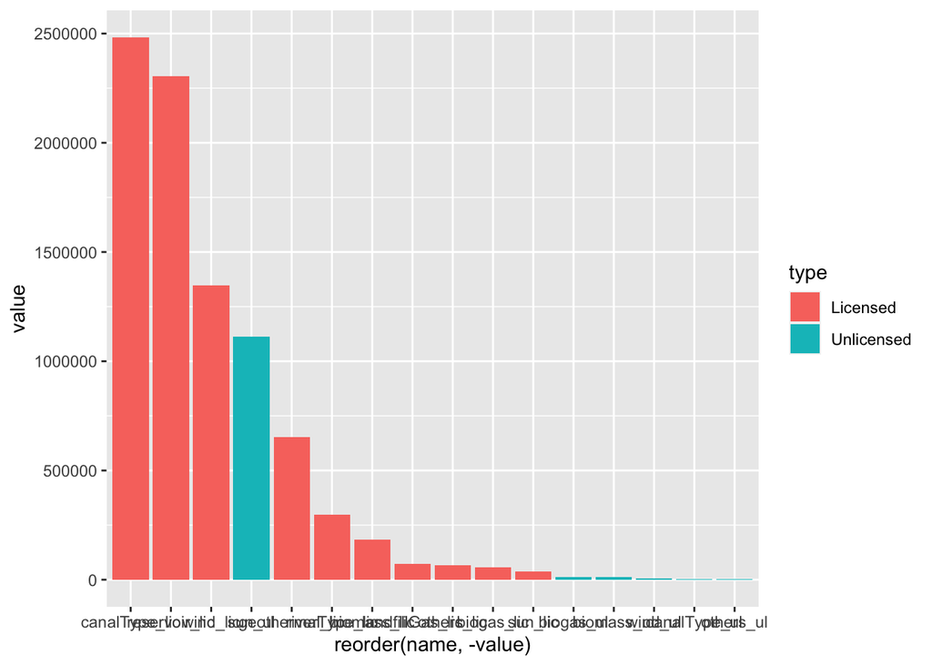

```r
ggplot(plot_df3,aes(x=reorder(name,-value),y=value)) + geom_bar(stat="identity",aes(fill=type))
```

### Pie Chart

Pie chart is actually a bar chart with an extra (`coord_polar`).

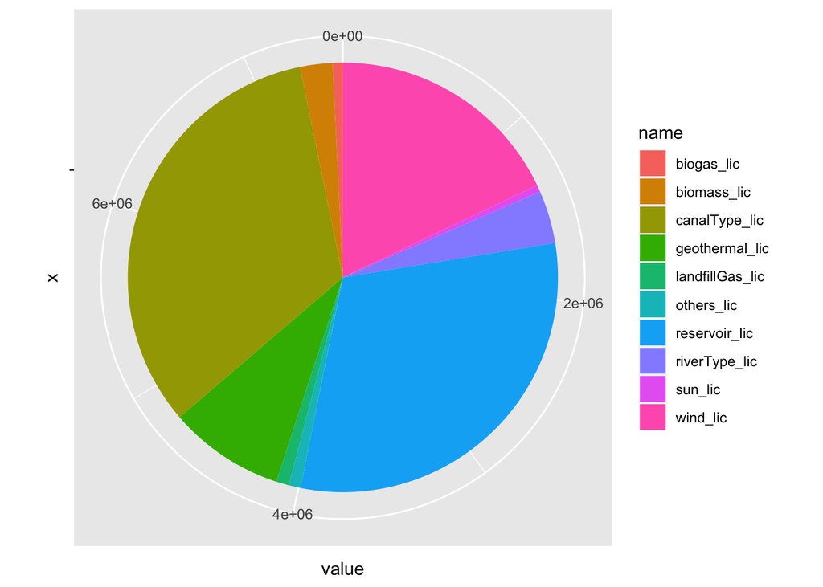

```r
ggplot(plot_df3 %>% filter(type=="Licensed"),aes(x="",y=value,fill=name)) + geom_bar(stat="identity",width=1) + coord_polar("y")
```